# **MATH 3190 Homework 2**

Due February 5, 2026  
Focus: Notes 4  
Total Points: 65 + 10 (Self-Critique Comment and Uploading to GitHub) = 75

Note that your homework should be completed in Quarto. You can just add your answers and code to this document in the appropriate part. The file should be rendered as an html document or pdf document (html is quicker to render and you will need an installation of LaTeX to render as a pdf). You will “turn in” this homework by uploading the files, the .qmd and output file, to your GitHub `Math_3190_Assignment` repository in the `Homework/Homework_2` directory. Make sure all supporting files (if there are any) are in this directory as well. You should use `git` and `Unix` commands in a terminal for this (i.e. don’t manually upload files to GitHub). In addition, you will submit just your html or pdf file on Canvas to unlock the solutions.

Don’t forget to also put a self-critique comment on Canvas indicating what you did correctly and incorrectly and include any questions you may have about the assignment after submitting the assignment and thoroughly looking through the solutions.

# Problem 1 (65 points)

It is time to practice using SQL. First, we will need some files that are worthy of being treated as databases. For this, you will need a little more than 1 GB of hard drive space. Alternatively, you should be able to store these files on your OneDrive. Go ahead and download all of the files from this link: https://suu-my.sharepoint.com/:f:/g/personal/richardbrown1_suu_edu/IgCX2W7pUzK1QIsVpB1dbIF_AQc_ii3Jwm9eHWDBm2xCAyk?e=GeszqA. While the `airports.csv` and `airlines.csv` files are quite small, the `flights.csv` is over 565 MB in size and contains the records of 5,819,079 flights in USA in 2015. These data came from the [Bureau of Transportation Statistics](https://www.transtats.bts.gov). **Make sure you save these file outside of your Math_3190_Assignments since you will not be able to push the `flights.csv` file to GitHub due to its size.**

### Part a (5 points)

While it is probable that your computer could read in this data set in its entirety, we are going to avoid that and instead make a database that we can access using SQL. Follow the example on slides 55-57 of Notes 4 to create a `.sqlite` file that contains the tables `flights` (from `flights.csv`), `airports` (from `airports.csv`), and `airlines` (from `airlines.csv`). **Again, make sure you save this `.sqlite` file outside of your Math_3190_Assignments since you will not be able to push it to GitHub due to its size.**

```r
# setwd("C:\\Users\\Samuel\\Desktop\\R-scripts-and-data\\MATH3190\\MATH3190-Assignments\\homework\\homework2")
# install.packages("devtools")
```

```r
library(tidyverse)
library(devtools)
```

```r
# devtools::install_github("inbo/inborutils")
# devtools::install_github("rbrown53/math3190package")

#make .sqlite file
con <- DBI::dbConnect(RSQLite::SQLite(), ":memory:")
flight_files <- list.files("..\\..\\..\\BigData\\flightsFiles")
for (file in flight_files) {
data_file <- read.csv(paste0("..\\..\\..\\BigData\\flightsFiles\\", file))
# Add data frame as a table
DBI::dbWriteTable(con, substr(file, 1, nchar(file) - 4), data_file)
rm(data_file)
}
```

### Part b (2 points)

Connect to the `.sqlite` database that you created in Part a like we did on slide 52 of Notes 5. Then use the `dbListTable()` function on that connection to list all the tables in the database. There should be three tables that you added in Part a.

```r
# Note that the connection filepath may need to be moved to match your specific computer's file structure. I have my large data files in a "BigData" folder outside of the MATH3190-Assignments folder.
con <- DBI::dbConnect(RSQLite::SQLite(),
"..\\..\\..\\BigData\\flights.sqlite")
DBI::dbListTables(con) # List all database tables
```

```
[1] "airlines" "airports" "flights"
```

### Part c (1 point)

There are many different types of SQL databases: MySQL, SQLite, SQL Server, etc. We created a SQLite database in Part a. A way to see all the columns of a table in an SQLite database is with the command `PRAGMA table_info('table_name')`. Using your connection from Part b, use the `dbGetQuery()` function in an **R** code chunk to print all the column names from the `flights` table. This is useful when we have a large file that is hard to even open to see what variables are in there.

```r
DBI::dbGetQuery(con, "PRAGMA table_info('flights')")
```

```
   cid                name type notnull dflt_value pk
1    0                YEAR REAL       0         NA  0
2    1               MONTH REAL       0         NA  0
3    2                 DAY REAL       0         NA  0
4    3         DAY_OF_WEEK REAL       0         NA  0
5    4             AIRLINE TEXT       0         NA  0
6    5       FLIGHT_NUMBER REAL       0         NA  0
7    6         TAIL_NUMBER TEXT       0         NA  0
8    7      ORIGIN_AIRPORT TEXT       0         NA  0
9    8 DESTINATION_AIRPORT TEXT       0         NA  0
10   9 SCHEDULED_DEPARTURE TEXT       0         NA  0
11  10      DEPARTURE_TIME TEXT       0         NA  0
12  11     DEPARTURE_DELAY REAL       0         NA  0
13  12            TAXI_OUT REAL       0         NA  0
14  13          WHEELS_OFF TEXT       0         NA  0
```

[output cut: 17 more lines]

```r
DBI::dbGetQuery(con, "PRAGMA table_info('airlines')")
```

```
  cid      name type notnull dflt_value pk
1   0 IATA_CODE TEXT       0         NA  0
2   1   AIRLINE TEXT       0         NA  0
```

```r
DBI::dbGetQuery(con, "PRAGMA table_info('airports')")
```

```
  cid      name type notnull dflt_value pk
1   0 IATA_CODE TEXT       0         NA  0
2   1   AIRPORT TEXT       0         NA  0
3   2      CITY TEXT       0         NA  0
4   3     STATE TEXT       0         NA  0
5   4   COUNTRY TEXT       0         NA  0
6   5  LATITUDE REAL       0         NA  0
7   6 LONGITUDE REAL       0         NA  0
```

### Part d (24 points)

Again using the `dbGetQuery()` function (one query per part) in an **R** code chunk, use SQL statements to answer the following questions. Note that distances are in miles.

1. What is the average distance of all flights in the US in 2015?
2. What is the minimum flight distance of all flights in the US in 2015?
3. What is the maximum flight distance of all flights in the US in 2015?
4. Between what two airports did the minimum distance flight take place?
5. Between what two airports did the maximum distance flight take place? The `SELECT DISTINCT` command will be useful here.
6. You might notice that some airports are coded with numbers instead of their IATA codes. Repeat item 5, but do not include the airports that begin with a “1”.
7. While you may know what these airports codes are, it would be nice if the full name of the airport was printed. The airport code information is in the `airport` table in your database in the `IATA_CODE` variable. Use the `INNER JOIN` statement to output the airport name for the two airports that have the minimum flight distance. Note that this command can take a few seconds to run.
8. Repeat item 7 with the maximum flight distances.

```r
distance = (DBI::dbGetQuery(con, "SELECT distance FROM flights WHERE year = 2015") )
mean(distance$DISTANCE)
```

```
[1] 822.3565
```

```r
min(distance$DISTANCE)
```

```
[1] 21
```

```r
max(distance$DISTANCE)
```

```
[1] 4983
```

```r
minDistanceLocation = (DBI::dbGetQuery(con, "SELECT origin_airport, destination_airport FROM flights WHERE distance = 21 AND year = 2015") )
print(minDistanceLocation)
```

```
  ORIGIN_AIRPORT DESTINATION_AIRPORT
1            EWR                 JFK
```

```r
maxDistanceLocation = (DBI::dbGetQuery(con, "SELECT DISTINCT origin_airport, destination_airport FROM flights WHERE distance = 4983 AND year = 2015") )
print(maxDistanceLocation)
```

```
  ORIGIN_AIRPORT DESTINATION_AIRPORT
1            JFK                 HNL
2            HNL                 JFK
3          12478               12173
4          12173               12478
```

```r
maxDistanceLocation = (DBI::dbGetQuery(con, "SELECT DISTINCT origin_airport, destination_airport FROM flights WHERE distance = 4983 AND year = 2015 AND origin_airport LIKE '___' "))
print(maxDistanceLocation)
```

```
  ORIGIN_AIRPORT DESTINATION_AIRPORT
1            JFK                 HNL
2            HNL                 JFK
```

```r
minDistanceDestinationLocationWithoutCode = (DBI::dbGetQuery(con, "SELECT DISTINCT airports.airport FROM flights INNER JOIN airports ON flights.destination_airport = airports.iata_code WHERE distance = 21 AND year = 2015 AND origin_airport LIKE '___'"))

minDistanceOriginLocationWithoutCode = (DBI::dbGetQuery(con, "SELECT DISTINCT airports.airport FROM flights INNER JOIN airports ON flights.origin_airport = airports.iata_code WHERE distance = 21 AND year = 2015 AND origin_airport LIKE '___' "))

print(minDistanceOriginLocationWithoutCode$AIRPORT)
```

```
[1] "Newark Liberty International Airport"
```

```r
print(minDistanceDestinationLocationWithoutCode$AIRPORT)
```

```
[1] "John F. Kennedy International Airport (New York International Airport)"
```

```r
maxDistanceDestinationLocationWithoutCode = (DBI::dbGetQuery(con, "SELECT DISTINCT airports.airport FROM flights INNER JOIN airports ON flights.destination_airport = airports.iata_code WHERE distance = 4983 AND year = 2015 AND origin_airport LIKE '___'"))

maxDistanceOriginLocationWithoutCode = (DBI::dbGetQuery(con, "SELECT DISTINCT airports.airport FROM flights INNER JOIN airports ON flights.origin_airport = airports.iata_code WHERE distance = 4983 AND year = 2015 AND origin_airport LIKE '___' "))

print(maxDistanceOriginLocationWithoutCode$AIRPORT)
```

```
[1] "John F. Kennedy International Airport (New York International Airport)"
[2] "Honolulu International Airport"
```

```r
print(maxDistanceDestinationLocationWithoutCode$AIRPORT)
```

```
[1] "Honolulu International Airport"
[2] "John F. Kennedy International Airport (New York International Airport)"
```

## Part e (11 points)

Many of these queries are generating outputs that are fairly small. That is, they are easily able to be stored as variables in **R**. A couple hundred thousand rows is fine to work with since that only takes a couple MB of RAM.

1. Using the `dbGetQuery()` function again, obtain the arrival delay times and the name of the airline (by joining with the airlines table) for all the data entries that have a delay time more than 60 minutes. Save this output as a tibble in **R**.

```r
delayAirlines = (DBI::dbGetQuery(con, "SELECT airlines.airline, flights.arrival_delay FROM flights INNER JOIN airlines ON flights.airline = airlines.iata_code WHERE arrival_delay > 60"))

print(head(delayAirlines))
```

```
                 AIRLINE ARRIVAL_DELAY
1        JetBlue Airways            85
2        JetBlue Airways            89
3 American Airlines Inc.           102
4 American Airlines Inc.            66
5  United Air Lines Inc.            78
6   Delta Air Lines Inc.           128
```

2. Once you have this, make side-by-side boxplots in `ggplot()` for the arrival delay time split by the airline. This plot won’t look too great unless the y-axis is scaled. Go ahead and use the log10 scale like we did back in Lab 2. Then look up how to angle the axis labels so they do not overlap and incorporate that in your plot.

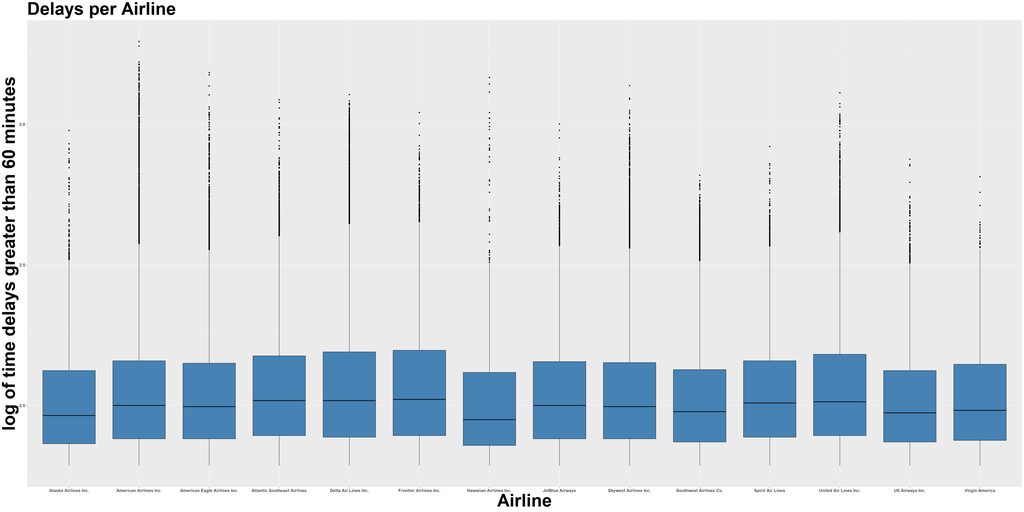

```r
#boxplot function I made earlier
box = function(values, by,X,Y,Title){
  df = data.frame(values, by)
  ggplot(df, aes(x = by, y = values)) +
    geom_boxplot(color = "black", fill = "steelblue") +
    labs(x = X, y = Y,title = Title) +
    scale_fill_brewer() +
    theme(plot.title = element_text(size = 50, face = "bold"), text = element_text(size = 15, face = "bold"), axis.title = element_text(size = 50,face = "bold"))
}

box(log(delayAirlines$ARRIVAL_DELAY,10), delayAirlines$AIRLINE, "Airline", "log of time delays greater than 60 minutes", "Delays per Airline")
```

### Part f (10 points)

1. Now, let’s NOT use the `dbGetQuery()` function. Instead, insert an SQL code chunk for this part of the problem that selects the **average** arrival delay (for some reason, there is not a median function built in to SQL) and the airline’s full name for each airline. So, this output should only have 14 rows.

```sql
SELECT airlines.airline, AVG(flights.arrival_delay) AS 'Average Delay' FROM flights INNER JOIN airlines ON flights.airline = airlines.iata_code WHERE arrival_delay > 60 GROUP BY airlines.airline
```

Displaying records 1 - 10

| AIRLINE | Average Delay |
| --- | --- |
| Alaska Airlines Inc. | 116.4731 |
| American Airlines Inc. | 132.0572 |
| American Eagle Airlines Inc. | 125.0035 |
| Atlantic Southeast Airlines | 127.5204 |
| Delta Air Lines Inc. | 137.4013 |
| Frontier Airlines Inc. | 137.0544 |
| Hawaiian Airlines Inc. | 131.2666 |
| JetBlue Airways | 121.0388 |
| Skywest Airlines Inc. | 124.2398 |
| Southwest Airlines Co. | 114.5414 |

2. Then pass this output back to **R** and create a barplot with the airlines on the x-axis and the average arrival delay on the y-axis. Again, angle the x-axis labels so they do not overlap.

```sql
SELECT airlines.airline, AVG(flights.arrival_delay) AS 'Average Delay' FROM flights INNER JOIN airlines ON flights.airline = airlines.iata_code WHERE arrival_delay > 60 GROUP BY airlines.airline
```

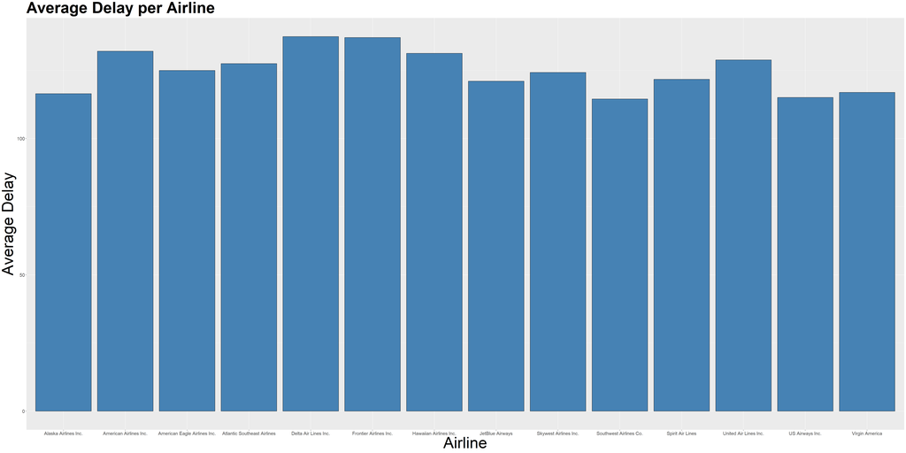

```r
#borplot function I made
bar = function(values, by,X,Y,Title){
  df = data.frame(values, by)
ggplot(df, aes(x = by, y = values)) +
  geom_bar(stat = "identity", color = "black", fill = "steelblue") +
  labs(x = X, y = Y) +
  ggtitle(Title) +
  theme(axis.title = element_text(size = 50),
        axis.text = element_text(size = 15),
        plot.title = element_text(size = 50, face = "bold"))
}

bar(avgAirDelay$`Average Delay`, avgAirDelay$AIRLINE, "Airline", "Average Delay", "Average Delay per Airline")
```

### Part g (12 points)

1. Now let’s use the `dbplyr` add-on to the `dplyr` package to work with an SQL database directly. You may have to install the `dbplyr` package. Use the `tbl()` function to create an object you can work with directly.

```r
library(dbplyr)
library(dplyr)
flights = tbl(con, "flights")
airlines = tbl(con, "airlines")
fullData = inner_join(flights,airlines, by = c("AIRLINE" = "IATA_CODE"))
# pull(fullData, AIRLINE.y)
```

2. With that object, using **R** commands from the tidyverse, find the average and standard deviation of the elapsed time of the flights by airline and arrange it by the SD (with the largest at the top). Make sure to use the `inner_join()` function so that the name of the airline, not just its code, is given. Note that to save this object in **R**’s memory, you will need to do something like pipe it into the `collect()` function.

```r
time_summary <- fullData |>
group_by(AIRLINE.y) |>
summarize(avg_time = mean(ELAPSED_TIME), sd_time = sd(ELAPSED_TIME)) |>
arrange(desc(sd_time))
head(time_summary)
```

```
# Source:     SQL [?? x 3]
# Database:   sqlite 3.51.1 [C:\Users\Samuel\Desktop\R-scripts-and-data\MATH3190\BigData\flights.sqlite]
# Ordered by: desc(sd_time)
  AIRLINE.y              avg_time sd_time
  <chr>                     <dbl>   <dbl>
1 Hawaiian Airlines Inc.     103.   124.
2 Virgin America             206.   112.
3 Alaska Airlines Inc.       179.    90.3
4 United Air Lines Inc.      191.    87.8
5 JetBlue Airways            168.    82.8
6 US Airways Inc.            152.    79.3
```

3. Finally, make a ggplot bar graph like the one you made in Part f, but use the standard deviation as the heights on the y-axis. Why do you suppose the airline with the largest standard deviation in elapsed time has such variable flight times?

Hawaiian Airlines is simply furthest from all other airlines in the data. This also explains why Alaskan Airlines is high on the list too.

[figure not shown]

```r
time_summary = as.data.frame(time_summary)

bar(time_summary$sd_time, time_summary$AIRLINE.y, "Airline", "Standard Dieviation of Delay", "Standard Dieviation of Delay per Airline")
```

Finally, when you are done with this assignment, it is good practice to close the connection to the flights database.

```r
DBI::dbDisconnect(con)
```